# Report About Corona Virus Cases in Croatia

M.M.G.S.Madhuranga

10/3/2022

### Introduction

Croatia is a Central European and Mediterranean nation that shares lengthy maritime borders with Italy in the Adriatic Sea and borders Slovenia to the west, Hungary to the north, Serbia to the east, and Bosnia and Herzegovina to the south. Together, these borders measure 2,028 km.

Croatia is unlike any other country in the world and has a peculiar shape (like a croissant!). The Ottoman (Turkish) empire’s five centuries of expansion into Central Europe are what gave it this peculiar shape. (However, despite this, the Turks never fully took control of Croatia; they did, however, rule over parts of its neighbors, including Serbia and Bosnia and Hercegovina.) On our history of Croatia page, we have more information about Croatia’s past if that interests you.

With a land area of 56,691 square kilometers and a population of 3.88 million, Croatia is a large country (2021 census â quite a fall from 4.29 million people recorded in the 2011 census). There are minorities of Serbian, Bosnian, Hungarian, and Italian in addition to the almost 90% Croat (most of whom are Roman Catholic) majority.

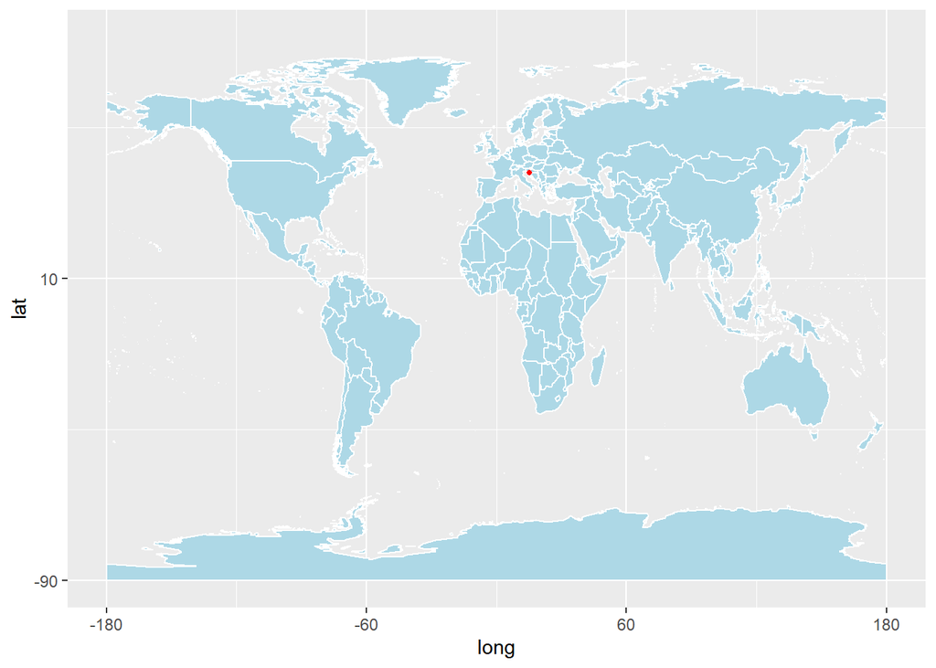

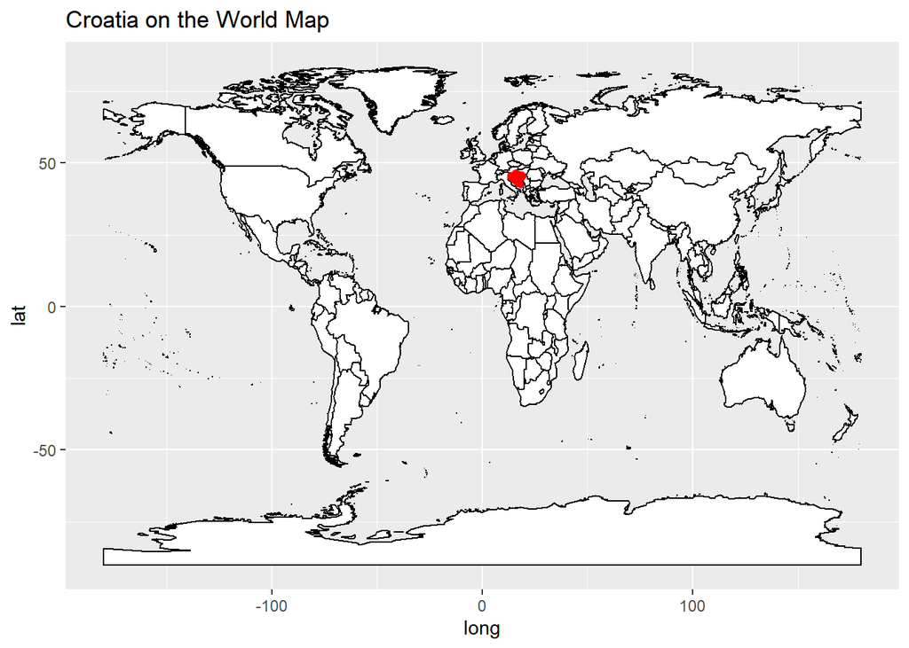

#### This is a summary of the Croatia coronaviris data.

```
##       date              province           country               lat
##  Min.   :2020-01-22   Length:2652        Length:2652        Min.   :45.1
##  1st Qu.:2020-08-29   Class :character   Class :character   1st Qu.:45.1
##  Median :2021-04-07   Mode  :character   Mode  :character   Median :45.1
##  Mean   :2021-04-07                                         Mean   :45.1
##  3rd Qu.:2021-11-14                                         3rd Qu.:45.1
##  Max.   :2022-06-23                                         Max.   :45.1
##       long          type               cases                uid
##  Min.   :15.2   Length:2652        Min.   :-354830.0   Min.   :191
##  1st Qu.:15.2   Class :character   1st Qu.:      1.0   1st Qu.:191
##  Median :15.2   Mode  :character   Median :     38.0   Median :191
##  Mean   :15.2                      Mean   :    437.2   Mean   :191
##  3rd Qu.:15.2                      3rd Qu.:    379.0   3rd Qu.:191
##  Max.   :15.2                      Max.   :  11812.0   Max.   :191
##      iso2               iso3               code3     combined_key
##  Length:2652        Length:2652        Min.   :191   Length:2652
##  Class :character   Class :character   1st Qu.:191   Class :character
##  Mode  :character   Mode  :character   Median :191   Mode  :character
##                                        Mean   :191
##                                        3rd Qu.:191
##                                        Max.   :191
##    population      continent_name     continent_code
##  Min.   :4105268   Length:2652        Length:2652
##  1st Qu.:4105268   Class :character   Class :character
##  Median :4105268   Mode  :character   Mode  :character
##  Mean   :4105268
##  3rd Qu.:4105268
##  Max.   :4105268
```

#### Following dataframe shows the Confirmed corona virus cases in Croatia.

```
##         date province country  lat long      type cases uid iso2 iso3 code3
## 1 2020-01-22     <NA> Croatia 45.1 15.2 confirmed     0 191   HR  HRV   191
## 2 2020-01-23     <NA> Croatia 45.1 15.2 confirmed     0 191   HR  HRV   191
## 3 2020-01-24     <NA> Croatia 45.1 15.2 confirmed     0 191   HR  HRV   191
## 4 2020-01-25     <NA> Croatia 45.1 15.2 confirmed     0 191   HR  HRV   191
## 5 2020-01-26     <NA> Croatia 45.1 15.2 confirmed     0 191   HR  HRV   191
## 6 2020-01-27     <NA> Croatia 45.1 15.2 confirmed     0 191   HR  HRV   191
##   combined_key population continent_name continent_code
## 1      Croatia    4105268         Europe             EU
## 2      Croatia    4105268         Europe             EU
## 3      Croatia    4105268         Europe             EU
## 4      Croatia    4105268         Europe             EU
## 5      Croatia    4105268         Europe             EU
## 6      Croatia    4105268         Europe             EU
```

```
## [1] 1143354
```

#### The total confirmed cases in Croatia in this data set is 1143354.

#### This graphs shows us how cofirmed cases reported in given years

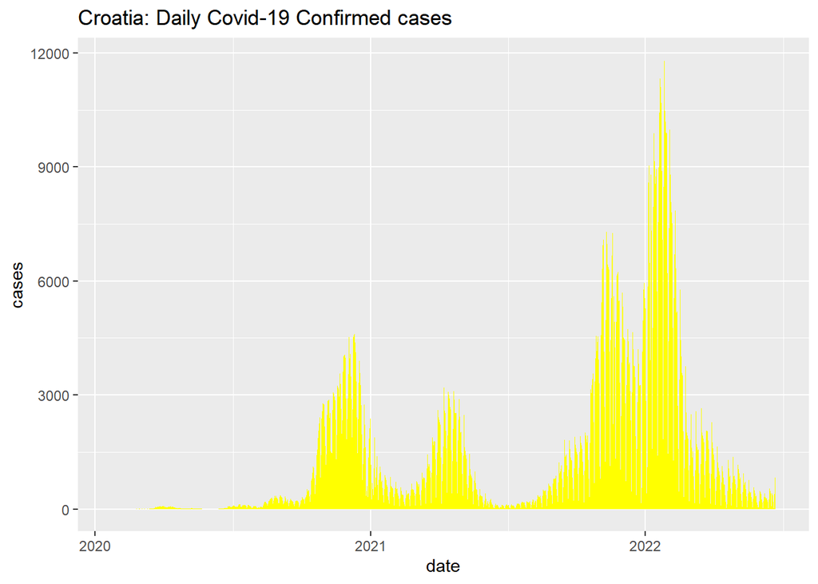

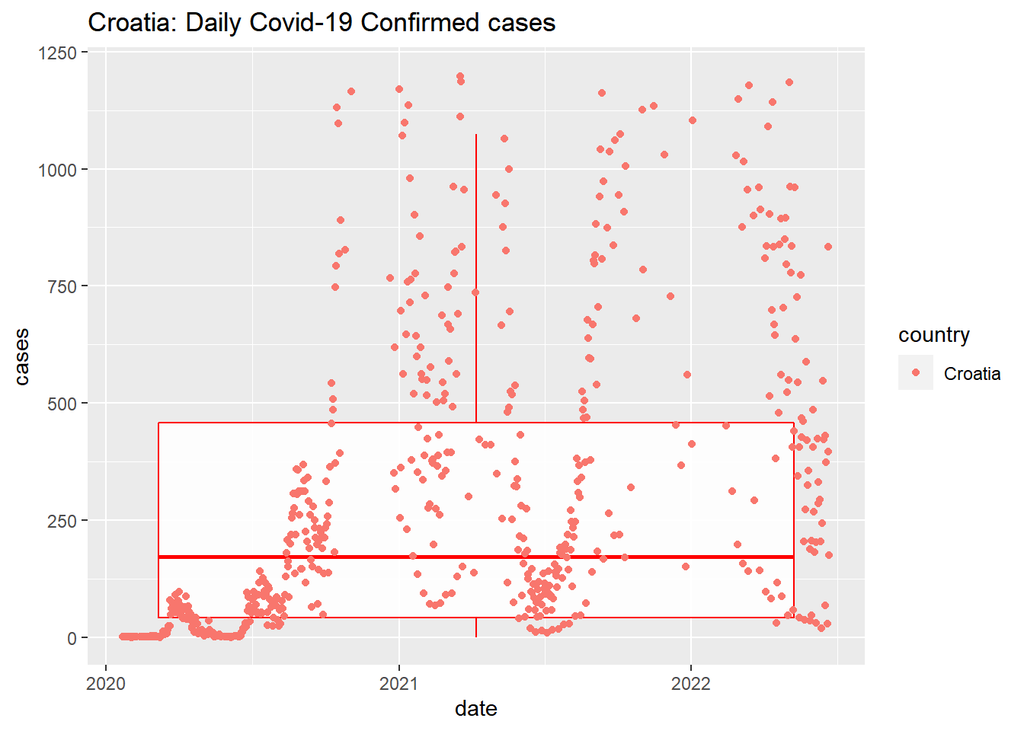

As we can see in this graph the number of confirmed cases in Croatia were increacing over the year. rapidly increased in end of the year 2021 and begining of 2022 and it came to a peak value in 1st quarter of 2022. The speciality of this data set is,we can see a pattern throughout the graph.

#### Following dataframe shows the Death cases in Croatia cause of the Corona virus.

```
##         date province country  lat long  type cases uid iso2 iso3 code3
## 1 2020-01-22     <NA> Croatia 45.1 15.2 death     0 191   HR  HRV   191
## 2 2020-01-23     <NA> Croatia 45.1 15.2 death     0 191   HR  HRV   191
## 3 2020-01-24     <NA> Croatia 45.1 15.2 death     0 191   HR  HRV   191
## 4 2020-01-25     <NA> Croatia 45.1 15.2 death     0 191   HR  HRV   191
## 5 2020-01-26     <NA> Croatia 45.1 15.2 death     0 191   HR  HRV   191
## 6 2020-01-27     <NA> Croatia 45.1 15.2 death     0 191   HR  HRV   191
##   combined_key population continent_name continent_code
## 1      Croatia    4105268         Europe             EU
## 2      Croatia    4105268         Europe             EU
## 3      Croatia    4105268         Europe             EU
## 4      Croatia    4105268         Europe             EU
## 5      Croatia    4105268         Europe             EU
## 6      Croatia    4105268         Europe             EU
```

#### The total Death cases in Croatia in this data set is 16043

```
## [1] 16043
```

#### This graphs shows us how Death cases reported in given years

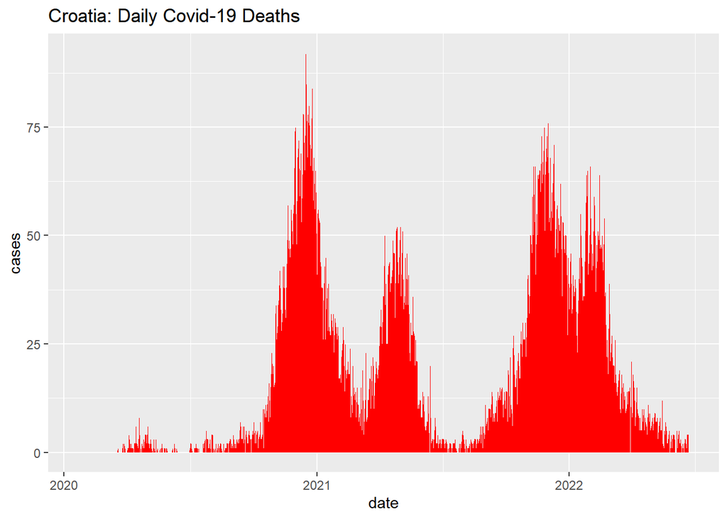

In this graph we can see that the deaths in Croatia was in its peak point in the end of the year 2020. The deaths were decreased till the middle of the year 2021 and it were increased again. We can see a pattern like this until the end of the year 2022.The total deaths in Croatia in this data set is only 16043. Itâs approximately 1.4% from the confirmed cases in Croatia.

#### The following dataframe shows the recovered coronavirus cases in Croatia.

```
##         date province country  lat long     type cases uid iso2 iso3 code3
## 1 2020-01-22     <NA> Croatia 45.1 15.2 recovery     0 191   HR  HRV   191
## 2 2020-01-23     <NA> Croatia 45.1 15.2 recovery     0 191   HR  HRV   191
## 3 2020-01-24     <NA> Croatia 45.1 15.2 recovery     0 191   HR  HRV   191
## 4 2020-01-25     <NA> Croatia 45.1 15.2 recovery     0 191   HR  HRV   191
## 5 2020-01-26     <NA> Croatia 45.1 15.2 recovery     0 191   HR  HRV   191
## 6 2020-01-27     <NA> Croatia 45.1 15.2 recovery     0 191   HR  HRV   191
##   combined_key population continent_name continent_code
## 1      Croatia    4105268         Europe             EU
## 2      Croatia    4105268         Europe             EU
## 3      Croatia    4105268         Europe             EU
## 4      Croatia    4105268         Europe             EU
## 5      Croatia    4105268         Europe             EU
## 6      Croatia    4105268         Europe             EU
```

#### Recovered cases cannot be a negative value. Therefore I took the mean value of nearest data and replace the mean value to the minus value.

```
## [1] NA
```

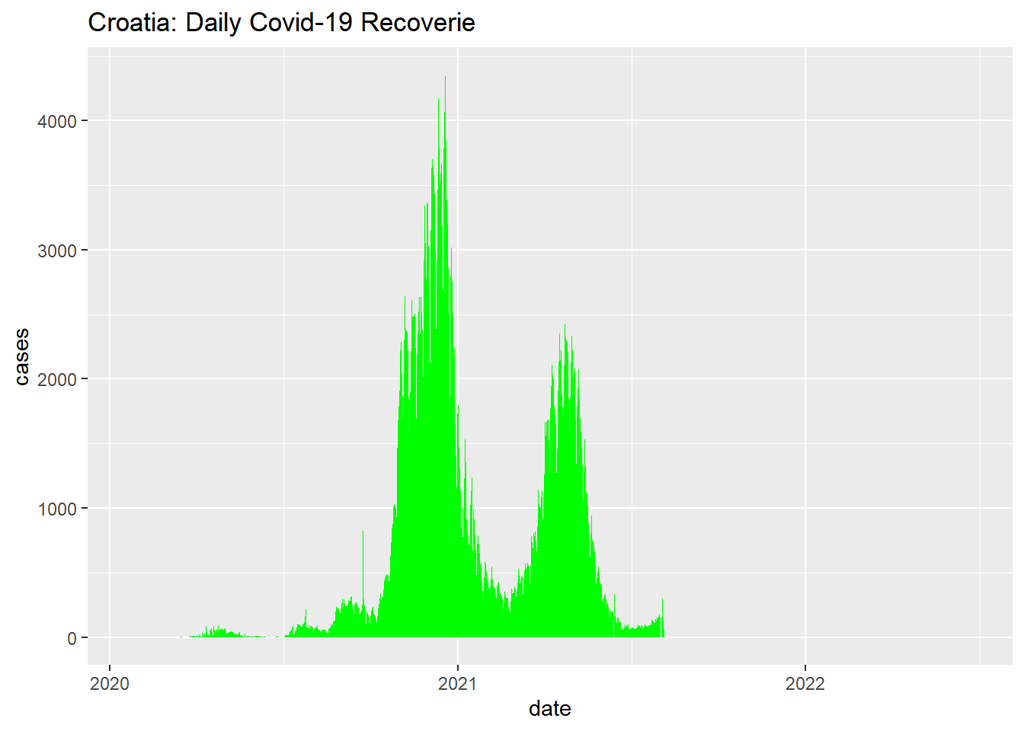

In this graph we can see that recovered cases high in end of the year 2020, that’s because in end of the year2020 confirmed cases were in a high level.Recovered cases are low in the middle of 2021. The total recovered cases in Croatia in this data set is only 354898. Itâs approximately 31.04% from the confirmed cases in Croatia.

#### Now we consider about the Active cases in Croatia.

#### This graph shows that how active cases were recorded in those years.

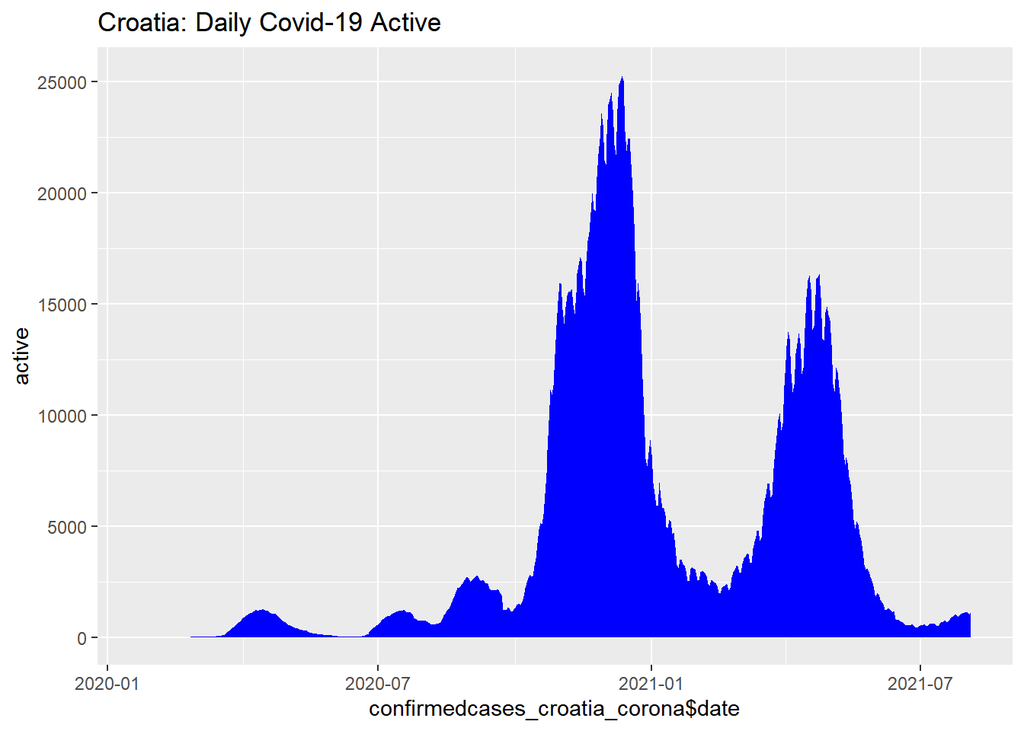

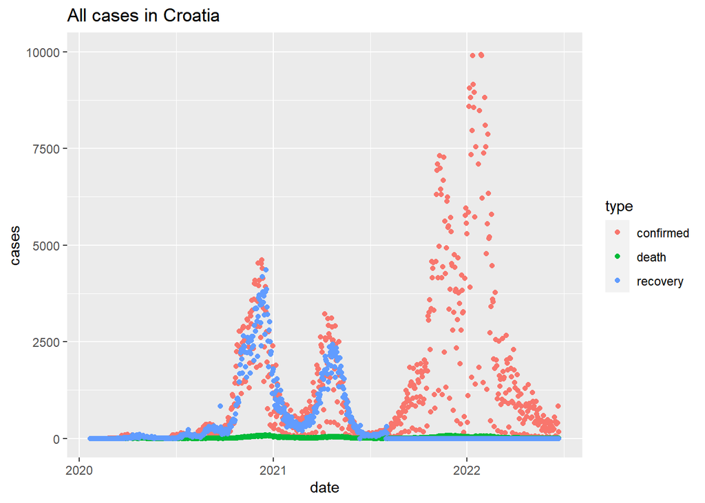

Above Graph shows us that the confirmed cases were the most recorded cases in Croatia in that given time period. With comparing Confirmed and recovered cases,Death cases are vey low in Croatia

#### Now we concider how Corona virus effected on Coratia’s Neighbour Countries.

#### This graph shows us about the confirmed cases in neighbour countries.

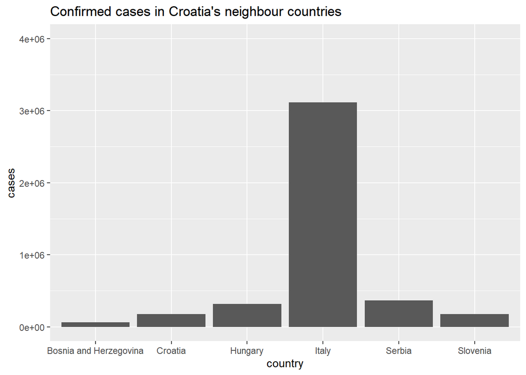

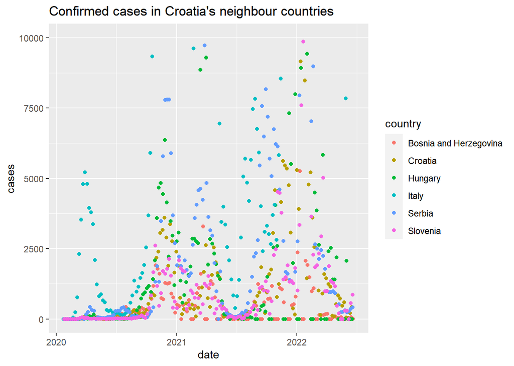

#### Using 1st graph we can consider that there were higher confirmed cases inItaly compared to other countries.The reason is Italy has the highest population. When considering Hungary and Serbia there were approximately same confirmed cases.Bosnia and Herzegovina had the least cases comparing to the other countries. When considering the 2nd graph we can see that Italy recorded higher outlier cases than other countries.

#### This graphs shows about the Recoveries in neighbour Countries.

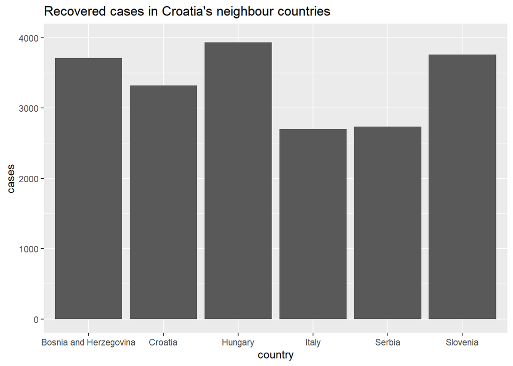

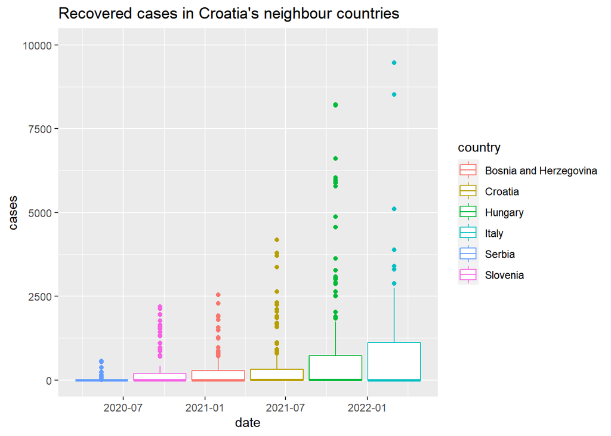

### This is about the death cases in neighbour countries.

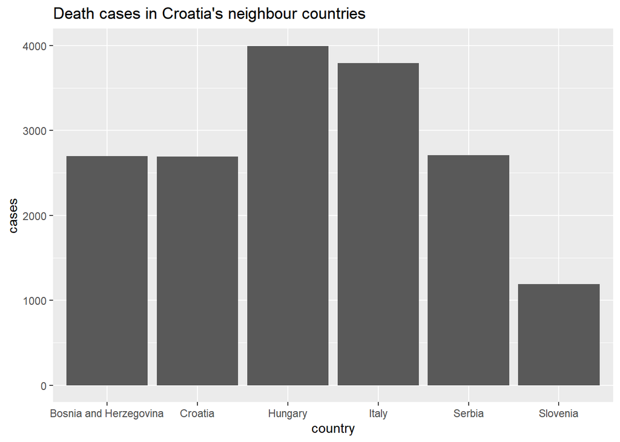

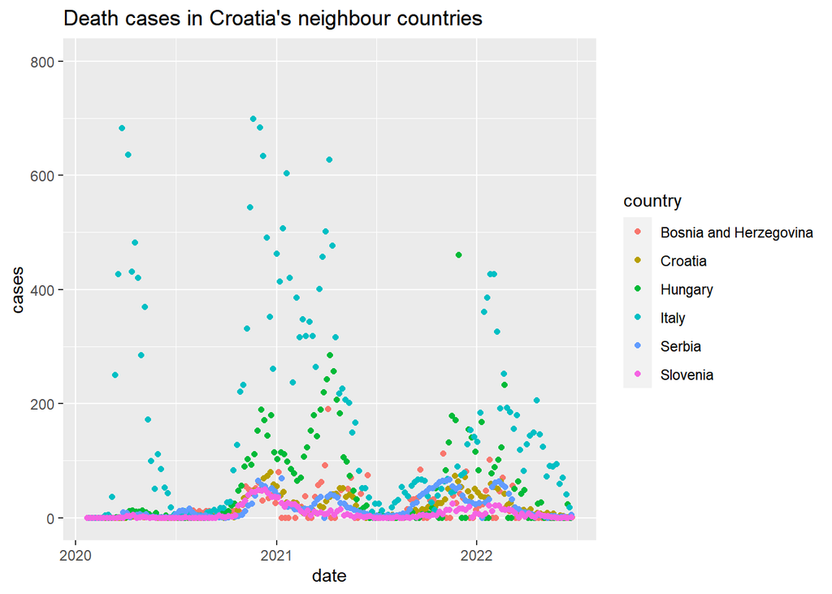

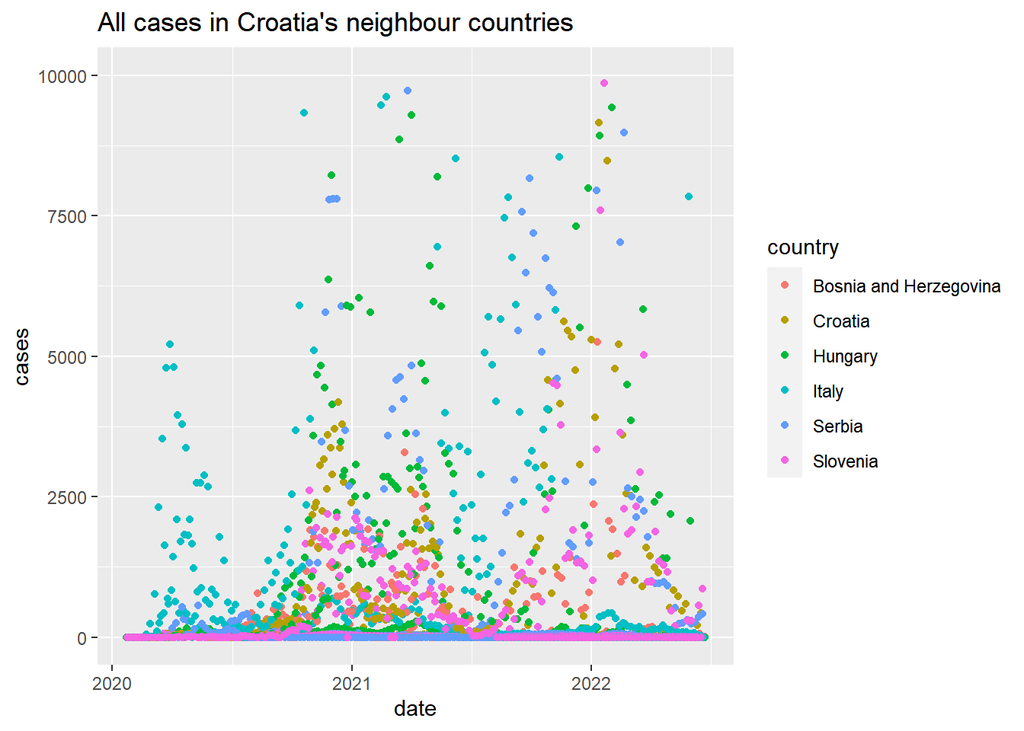

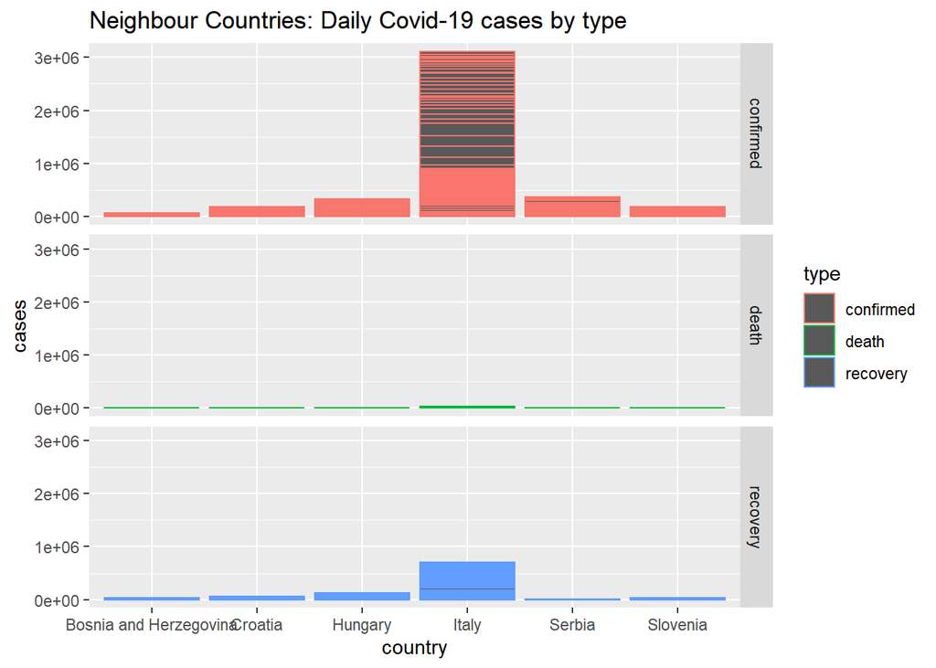

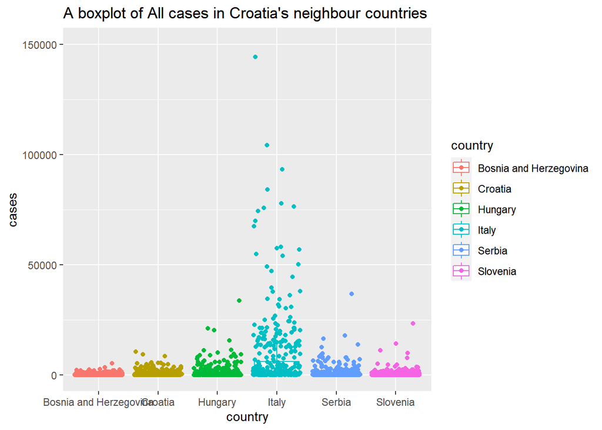

## Discussion

1143354 confirmed cases of COVID-19 and 16043 fatalities have been reported as a result of the COVID-19 pandemic in Croatia.

On February 25, a patient from Italy who had traveled to Zagreb was found to have the disease after testing positive. This was the country of Croatia’s first case. The second instance connected to the first one was confirmed on the same day. A number of incidents were recorded in different Croatian cities in March 2020. The first recovery was recorded on March 12 and the first confirmed virus-related death was discovered on March 18. .During Croatia’s time in office as EU Council president, a pandemic struck the country. The Croatian capital of Zagreb was struck by the largest earthquake in 140 years on March 22, 2020, which made it difficult to carry out the government’s plans for social segregation during the country’s lockdown in the latter portion of the first half of 2020. A national election for parliament was conducted on July 5, 2020. Local elections were held nationwide on May 16, 2021. During the summer of 2020, when tourists were most in demand, the nation was largely reopened.

## Refferences

[https://www.visit-croatia.co.uk/about-croatia/](https://www.visit-croatia.co.uk/about-croatia/,https://en.wikipedia.org/wiki/COVID-19_pandemic_in_Croatia)

https://en.wikipedia.org/wiki/COVID-19_pandemic_in_Croatia